# Full cycle example

```r
library(ggplot2)
library(tidyr)
library(dplyr)
```

## 1 Load data

Download data file [here](https://github.com/anselmrothe/ggplot/tree/master/data).

```r
dd <- read.csv("msleep.csv", stringsAsFactors = F)
```

- That was simple.
- In general, I find it easiest to have my data as `.csv` files.
- `stringsAsFactors = F` can save you from confusion later on.
- `dd` is a `data.frame`

*Backup: If you had problems loading the data, you can just use `dd <- msleep` instead (msleep is a built-in data set from the ggplot2 package).*

Ok, let’s have a look at the first rows.

```r
dd %>% head # which is the same as: head(dd)
```

```
##                         name      genus  vore        order conservation
## 1                    Cheetah   Acinonyx carni    Carnivora           lc
## 2                 Owl monkey      Aotus  omni     Primates         <NA>
## 3            Mountain beaver Aplodontia herbi     Rodentia           nt
## 4 Greater short-tailed shrew    Blarina  omni Soricomorpha           lc
## 5                        Cow        Bos herbi Artiodactyla domesticated
## 6           Three-toed sloth   Bradypus herbi       Pilosa         <NA>
##   sleep_total sleep_rem sleep_cycle awake brainwt  bodywt
## 1        12.1        NA          NA  11.9      NA  50.000
## 2        17.0       1.8          NA   7.0 0.01550   0.480
## 3        14.4       2.4          NA   9.6      NA   1.350
## 4        14.9       2.3   0.1333333   9.1 0.00029   0.019
## 5         4.0       0.7   0.6666667  20.0 0.42300 600.000
## 6        14.4       2.2   0.7666667   9.6      NA   3.850
```

This is data about mammals sleeping.

Another helpful command for getting an overview of an object in R is `str()` (structure).

```r
dd %>% str
```

```
## 'data.frame':    83 obs. of  11 variables:
##  $ name        : chr  "Cheetah" "Owl monkey" "Mountain beaver" "Greater short-tailed shrew" ...
##  $ genus       : chr  "Acinonyx" "Aotus" "Aplodontia" "Blarina" ...
##  $ vore        : chr  "carni" "omni" "herbi" "omni" ...
##  $ order       : chr  "Carnivora" "Primates" "Rodentia" "Soricomorpha" ...
##  $ conservation: chr  "lc" NA "nt" "lc" ...
##  $ sleep_total : num  12.1 17 14.4 14.9 4 14.4 8.7 7 10.1 3 ...
##  $ sleep_rem   : num  NA 1.8 2.4 2.3 0.7 2.2 1.4 NA 2.9 NA ...
##  $ sleep_cycle : num  NA NA NA 0.133 0.667 ...
##  $ awake       : num  11.9 7 9.6 9.1 20 9.6 15.3 17 13.9 21 ...
##  $ brainwt     : num  NA 0.0155 NA 0.00029 0.423 NA NA NA 0.07 0.0982 ...
##  $ bodywt      : num  50 0.48 1.35 0.019 600 ...
```

## 2 Reshape data

*(see [additional page](https://github.com/anselmrothe/ggplot/blob/master/2-reshape_data.md))*

Let’s focus on some columns

```r
ee <- dd %>% select(name, order, sleep_total, awake, brainwt, bodywt)
ee %>% head
```

```
##                         name        order sleep_total awake brainwt
## 1                    Cheetah    Carnivora        12.1  11.9      NA
## 2                 Owl monkey     Primates        17.0   7.0 0.01550
## 3            Mountain beaver     Rodentia        14.4   9.6      NA
## 4 Greater short-tailed shrew Soricomorpha        14.9   9.1 0.00029
## 5                        Cow Artiodactyla         4.0  20.0 0.42300
## 6           Three-toed sloth       Pilosa        14.4   9.6      NA
##    bodywt
## 1  50.000
## 2   0.480
## 3   1.350
## 4   0.019
## 5 600.000
## 6   3.850
```

Mammals sleeping? Any data on students sleeping in lectures?

```r
ee %>% filter(name == "student")
```

```
## [1] name        order       sleep_total awake       brainwt     bodywt
## <0 rows> (or 0-length row.names)
```

No.

But let’s get rid of all “Soricomorpha” order mammals because I don’t know what that is and it sounds weird.

```r
ee <- ee %>% filter(order != "Soricomorpha")
ee %>% head
```

```
##                name        order sleep_total awake brainwt bodywt
## 1           Cheetah    Carnivora        12.1  11.9      NA  50.00
## 2        Owl monkey     Primates        17.0   7.0  0.0155   0.48
## 3   Mountain beaver     Rodentia        14.4   9.6      NA   1.35
## 4               Cow Artiodactyla         4.0  20.0  0.4230 600.00
## 5  Three-toed sloth       Pilosa        14.4   9.6      NA   3.85
## 6 Northern fur seal    Carnivora         8.7  15.3      NA  20.49
```

Soricomorpha in row 4 is gone.

Let’s order the animals by awake time.

```r
ee <- ee %>% arrange(awake)
ee %>% head
```

```
##                     name           order sleep_total awake brainwt bodywt
## 1       Little brown bat      Chiroptera        19.9   4.1 0.00025  0.010
## 2          Big brown bat      Chiroptera        19.7   4.3 0.00030  0.023
## 3   Thick-tailed opposum Didelphimorphia        19.4   4.6      NA  0.370
## 4        Giant armadillo       Cingulata        18.1   5.9 0.08100 60.000
## 5 North American Opossum Didelphimorphia        18.0   6.0 0.00630  1.700
## 6   Long-nosed armadillo       Cingulata        17.4   6.6 0.01080  3.500
```

Oh, actually we wanted to have those that most time awake on top.

```r
ee <- ee %>% arrange(-awake)
ee %>% head
```

```
##               name          order sleep_total awake brainwt   bodywt
## 1          Giraffe   Artiodactyla         1.9 22.10      NA  899.995
## 2      Pilot whale        Cetacea         2.7 21.35      NA  800.000
## 3            Horse Perissodactyla         2.9 21.10  0.6550  521.000
## 4         Roe deer   Artiodactyla         3.0 21.00  0.0982   14.800
## 5           Donkey Perissodactyla         3.1 20.90  0.4190  187.000
## 6 African elephant    Proboscidea         3.3 20.70  5.7120 6654.000
```

For plotting with ggplot, the order of your rows does not matter (at least not for the types of plots we will use).

## 3 Plot data

Exploratory data analysis. This is going to be fun! By visualizing (with just with a few lines!) we will get more understanding of our data than fitting some models and staring at parameters for hours.

- scatterplot

Let’s take `awake` as our variable of interest. Are animals that spend more time sleeping, less time awake?

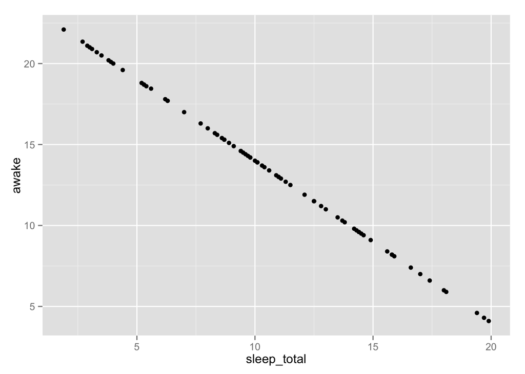

```r
ee %>% ggplot(aes(sleep_total, awake)) + geom_point()
```

Boring! (Ok this was a sanity check.)

Let’s try another variable.

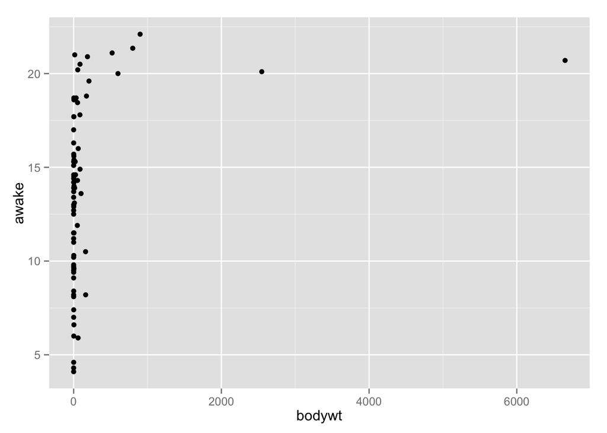

```r
ee %>% ggplot(aes(bodywt, awake)) + geom_point()
```

Better!

By the way, weight is in kg and time is in hours.

`...`